# Notebook

## Modelado de Regresión Lineal con Álgebra Matricial en Python

### Objetivo: Implementar un sistema en Python que utilice matrices y vectores para resolver un problema de regresión lineal simple utilizando álgebra matricial.

### 👥 **Alumno**

- **🧑‍🎓 José Gómez Brizuela**

📅 *Entrega: Junio 2025*  
📘 *Módulo 3: Sesión N° 1*

# Forma Matricial de los Coeficientes de Regresión

## Fórmula principal:

$$\boldsymbol{\beta} = (\mathbf{X}^T\mathbf{X})^{-1}\mathbf{X}^T\mathbf{y}$$

## Componentes matriciales:

### Matriz X (n × k):

$$\mathbf{X} = \begin{bmatrix} 1 & x_{11} & x_{12} & \cdots & x_{1,k-1} \\ 1 & x_{21} & x_{22} & \cdots & x_{2,k-1} \\ 1 & x_{31} & x_{32} & \cdots & x_{3,k-1} \\ \vdots & \vdots & \vdots & \ddots & \vdots \\ 1 & x_{n1} & x_{n2} & \cdots & x_{n,k-1} \end{bmatrix}$$

### Vector y (n × 1):

$$\mathbf{y} = \begin{bmatrix} y_1 \\ y_2 \\ y_3 \\ \vdots \\ y_n \end{bmatrix}$$

### Vector β (k × 1):

$$\boldsymbol{\beta} = \begin{bmatrix} \beta_0 \\ \beta_1 \\ \beta_2 \\ \vdots \\ \beta_{k-1} \end{bmatrix}$$

### Matriz X^T X (k × k):

$$\mathbf{X}^T\mathbf{X} = \begin{bmatrix} n & \sum x_{i1} & \sum x_{i2} & \cdots & \sum x_{i,k-1} \\ \sum x_{i1} & \sum x_{i1}^2 & \sum x_{i1}x_{i2} & \cdots & \sum x_{i1}x_{i,k-1} \\ \sum x_{i2} & \sum x_{i1}x_{i2} & \sum x_{i2}^2 & \cdots & \sum x_{i2}x_{i,k-1} \\ \vdots & \vdots & \vdots & \ddots & \vdots \\ \sum x_{i,k-1} & \sum x_{i1}x_{i,k-1} & \sum x_{i2}x_{i,k-1} & \cdots & \sum x_{i,k-1}^2 \end{bmatrix}$$

### Vector X^T y (k × 1):

$$\mathbf{X}^T\mathbf{y} = \begin{bmatrix} \sum y_i \\ \sum x_{i1}y_i \\ \sum x_{i2}y_i \\ \vdots \\ \sum x_{i,k-1}y_i \end{bmatrix}$$

## Resultado final:

$$\boldsymbol{\beta} = (\mathbf{X}^T\mathbf{X})^{-1}\mathbf{X}^T\mathbf{y} = \begin{bmatrix} \beta_0 \\ \beta_1 \\ \beta_2 \\ \vdots \\ \beta_{k-1} \end{bmatrix}$$

### Donde:

- **n** = número total de observaciones
- **k** = número total de parámetros (incluyendo intercepto)
- **∑** denota suma sobre todas las observaciones i = 1, 2, ..., n
- **β₀** = intercepto
- **βⱼ** = coeficiente de la j-ésima variable explicativa

## 1) Diseño e Implementación

Para imprimir la forma (shape) de cada matriz y resultado intermedio para reforzar el aprendizaje conceptual se utilizo la libreria Sympy y se creo una función especifica y universal que fue utilizada a lo largo del ejercicio.

```python
import numpy as np
import matplotlib.pyplot as plt
from sympy import Matrix
from sympy import init_printing

plt.rcParams['axes.labelsize'] = 12
plt.rcParams['xtick.labelsize'] = 10
plt.rcParams['ytick.labelsize'] = 10

# Activamos la impresión de SymPy para mostrar matrices de manera optima
init_printing()

def mostrar_matriz_formato(matriz, nombre="Matriz"):
    """
    Muestra una matriz de SymPy con formato matemático elegante.

    Parámetros:
    -----------
    matriz : sympy.Matrix
        Matriz a mostrar
    nombre : str
        Nombre de la matriz para la etiqueta
    """
    if not isinstance(matriz, Matrix):
        raise TypeError("Se esperaba una matriz de tipo sympy.Matrix.")

    filas, columnas = matriz.shape
    elementos_str = [[str(matriz[i, j]) for j in range(columnas)] for i in range(filas)]
    anchos = [max(max(len(row[j]) for row in elementos_str), 4) for j in range(columnas)]
    nombre_columna = f"{nombre} = "

    for i in range(filas):
        borde_izq = "⎡" if i == 0 else "⎢" if i < filas - 1 else "⎣"
        borde_der = "⎤" if i == 0 else "⎥" if i < filas - 1 else "⎦"
        linea = nombre_columna if i == 0 else " " * len(nombre_columna)
        linea += borde_izq
        for j in range(columnas):
            linea += elementos_str[i][j].rjust(anchos[j])
            if j < columnas - 1:
                linea += "  "
        linea += f" {borde_der}"
        print(linea)

def numpy_a_sympy(array_numpy, precision=4):
    """
    Convierte un array de NumPy a una matriz de SymPy con precisión controlada.

    Parámetros:
    -----------
    array_numpy : numpy.ndarray
        Array de NumPy a convertir
    precision : int
        Número de decimales para redondear

    Retorna:
    --------
    sympy.Matrix
        Matriz de SymPy equivalente
    """
    if array_numpy.ndim == 1:
        array_numpy = array_numpy.reshape(-1, 1)

    # Redondear para evitar números con muchos decimales
    array_redondeado = np.round(array_numpy, precision)
    return Matrix(array_redondeado.tolist())

def generar_datos(n=100):
    """
    Genera datos sintéticos para regresión lineal con ruido gaussiano.

    El modelo verdadero es: y = 4 + 3*x + ruido

    Parámetros:
    -----------
    n : int
        Número de observaciones a generar

    Retorna:
    --------
    x : numpy.ndarray
        Array de características de forma (n, 1)
    y : numpy.ndarray
        Array de valores observados de forma (n, 1)
    """
    print(f"🔸 Generando {n} observaciones...")

    # FijaMOS semilla para reproducibilidad Posterior
    np.random.seed(42)

    # Generar características x uniformemente distribuidas en [0, 1]
    x = np.random.rand(n, 1)
    print(f"   • x generado: forma {x.shape}, rango [{x.min():.3f}, {x.max():.3f}]")

    # Generar valores y con relación lineal + ruido gaussiano
    # Modelo verdadero: y = 4 + 3*x + ε, donde ε ~ N(0, 1)
    y = 4 + 3 * x + np.random.randn(n, 1)
    print(f"   • y generado: forma {y.shape}, rango [{y.min():.3f}, {y.max():.3f}]")
    print(f"   • Modelo verdadero: y = 4 + 3*x + ruido")

    return x, y

def demostrar_operaciones_matriciales(X, y):
    """
    Demuestra las operaciones matriciales básicas utilizadas en la regresión.

    Parámetros:
    -----------
    X : numpy.ndarray
        Matriz de diseño
    y : numpy.ndarray
        Vector de valores observados
    """
    print("\n" + "="*60)
    print("🔸 DEMOSTRACIÓN GRAFICA DE OPERACIONES MATRICIALES")
    print("="*60)

    # Convertir a matrices de SymPy para visualización elegante
    X_sympy = numpy_a_sympy(X[:8])  # Mostrar solo las primeras 8 filas
    y_sympy = numpy_a_sympy(y[:8])  # Mostrar solo los primeros 8 valores

    # 1. Información básica de las matrices
    print(f"🔹 Matriz de diseño X (primeras 8 filas):")
    print(f"   • Forma completa: {X.shape}")
    mostrar_matriz_formato(X_sympy, "X")

    print(f"\n🔹 Vector y (primeros 8 valores):")
    print(f"   • Forma completa: {y.shape}")
    mostrar_matriz_formato(y_sympy, "y")

    # 2. Transpuesta de X
    X_T = X.T
    X_T_sympy = numpy_a_sympy(X_T)
    print(f"\n🔹 Transpuesta X^T:")
    print(f"   • X^T tiene forma: {X_T.shape}")
    mostrar_matriz_formato(X_T_sympy, "X^T")

    # 3. Producto X^T @ X
    XTX = X_T @ X
    XTX_sympy = numpy_a_sympy(XTX)
    print(f"\n🔹 Producto X^T @ X:")
    print(f"   • (X^T @ X) tiene forma: {XTX.shape}")
    mostrar_matriz_formato(XTX_sympy, "X^T @ X")

    # 4. Determinante de X^T @ X
    det_XTX = np.linalg.det(XTX)
    print(f"   • Determinante de (X^T @ X): {det_XTX:.6f}")
    print(f"   • {'✓ Matriz invertible' if abs(det_XTX) > 1e-10 else '✗ Matriz singular'}")

    # 5. Inversa de X^T @ X
    XTX_inv = np.linalg.inv(XTX)
    XTX_inv_sympy = numpy_a_sympy(XTX_inv)
    print(f"\n🔹 Inversa (X^T @ X)^(-1):")
    mostrar_matriz_formato(XTX_inv_sympy, "(X^T @ X)^(-1)")

    # 6. Verificación de la inversa
    identidad = XTX @ XTX_inv
    identidad_sympy = numpy_a_sympy(identidad)
    print(f"\n🔹 Verificación de la inversa:")
    print(f"   • (X^T @ X) @ (X^T @ X)^(-1) =")
    mostrar_matriz_formato(identidad_sympy, "Identidad")
    print(f"   • {'✓ Inversa correcta' if np.allclose(identidad, np.eye(2)) else '✗ Error en la inversa'}")

    # 7. Producto X^T @ y
    XTy = X_T @ y
    XTy_sympy = numpy_a_sympy(XTy)
    print(f"\n🔹 Producto X^T @ y:")
    print(f"   • (X^T @ y) tiene forma: {XTy.shape}")
    mostrar_matriz_formato(XTy_sympy, "X^T @ y")

    return XTX_inv, XTy

def ajustar_modelo(x, y):
    """
    Calcula los parámetros β de la regresión lineal usando álgebra matricial.

    Implementa la fórmula: β = (X^T X)^(-1) X^T y

    Parámetros:
    -----------
    x : numpy.ndarray
        Array de características de forma (n, 1)
    y : numpy.ndarray
        Array de valores observados de forma (n, 1)

    Retorna:
    --------
    beta : numpy.ndarray
        Vector de parámetros ajustados [β₀, β₁]
    X : numpy.ndarray
        Matriz de diseño utilizada
    """
    print("\n" + "="*60)
    print("🔸 AJUSTE DEL MODELO DE REGRESIÓN LINEAL")
    print("="*60)

    n = x.shape[0]
    print(f"🔹 Construyendo matriz de diseño X:")

    # Crear matriz de diseño: columna de unos + columna de características
    columna_unos = np.ones((n, 1))
    X = np.hstack([columna_unos, x])

    print(f"   • Columna de unos: forma {columna_unos.shape}")
    print(f"   • Características x: forma {x.shape}")
    print(f"   • Matriz X final: forma {X.shape}")
    print(f"   • X = [columna_unos | x]")

    # Demostrar operaciones matriciales paso a paso
    XTX_inv, XTy = demostrar_operaciones_matriciales(X, y)

    # Calcular β = (X^T X)^(-1) X^T y
    print(f"\n🔹 Cálculo final de β:")
    print(f"   • Fórmula: β = (X^T X)^(-1) @ X^T @ y")

    beta = XTX_inv @ XTy
    beta_sympy = numpy_a_sympy(beta)

    print(f"   • Resultado:")
    mostrar_matriz_formato(beta_sympy, "β")

    print(f"   • β₀ (intercepto) = {beta[0, 0]:.6f}")
    print(f"   • β₁ (pendiente) = {beta[1, 0]:.6f}")

    # Comparar con valores verdaderos
    print(f"\n🔹 Comparación con modelo verdadero:")
    print(f"   • Verdadero: β₀ = 4.000, β₁ = 3.000")
    print(f"   • Estimado:  β₀ = {beta[0, 0]:.3f}, β₁ = {beta[1, 0]:.3f}")
    print(f"   • Error β₀: {abs(4 - beta[0, 0]):.6f}")
    print(f"   • Error β₁: {abs(3 - beta[1, 0]):.6f}")

    return beta, X

def calcular_metricas_modelo(y_real, y_pred):
    """
    Calcula métricas de evaluación del modelo.

    Parámetros:
    -----------
    y_real : numpy.ndarray
        Valores reales observados
    y_pred : numpy.ndarray
        Valores predichos por el modelo

    Retorna:
    --------
    dict : Diccionario con las métricas calculadas
    """
    # Error Cuadrático Medio (MSE)
    mse = np.mean((y_real - y_pred) ** 2)

    # Raíz del Error Cuadrático Medio (RMSE)
    rmse = np.sqrt(mse)

    # Error Absoluto Medio (MAE)
    mae = np.mean(np.abs(y_real - y_pred))

    # Coeficiente de Determinación (R²)
    ss_res = np.sum((y_real - y_pred) ** 2)  # Suma de cuadrados residuales
    ss_tot = np.sum((y_real - np.mean(y_real)) ** 2)  # Suma total de cuadrados
    r2 = 1 - (ss_res / ss_tot)

    return {
        'MSE': mse,
        'RMSE': rmse,
        'MAE': mae,
        'R²': r2,
        'SS_res': ss_res,
        'SS_tot': ss_tot
    }

def graficar_resultado(x, y, beta):
    """
    Grafica los datos originales y la recta de regresión ajustada.

    Parámetros:
    -----------
    x : numpy.ndarray
        Array de características
    y : numpy.ndarray
        Array de valores observados
    beta : numpy.ndarray
        Vector de parámetros ajustados [β₀, β₁]
    """
    print("\n" + "="*60)
    print("🔸 GENERANDO VISUALIZACIÓN")
    print("="*60)

    # Crear figura con subplots
    fig, (ax1, ax2) = plt.subplots(1, 2, figsize=(15, 6))

    # === GRÁFICO PRINCIPAL ===
    # Graficar datos originales
    ax1.scatter(x, y, color='steelblue', alpha=0.6, s=50,
                label='Datos observados', edgecolors='navy', linewidth=0.5)

    # Crear línea de regresión
    x_line = np.linspace(0, 1, 100).reshape(-1, 1)
    y_line_ajustada = beta[0] + beta[1] * x_line

    ax1.plot(x_line, y_line_ajustada, color='red', linewidth=3,
             label=f'Modelo ajustado: y = {beta[0,0]:.3f} + {beta[1,0]:.3f}x')

    # Línea del modelo verdadero para comparación
    y_line_verdadera = 4 + 3 * x_line
    ax1.plot(x_line, y_line_verdadera, color='green', linewidth=2,
             linestyle='--', label='Modelo verdadero: y = 4 + 3x')

    ax1.set_xlabel('x (Características)', fontsize=12)
    ax1.set_ylabel('y (Valores observados)', fontsize=12)
    ax1.set_title('Regresión Lineal - Ajuste del Modelo', fontsize=14, fontweight='bold')
    ax1.legend(fontsize=10)
    ax1.grid(True, alpha=0.3)

    # === GRÁFICO DE RESIDUOS ===
    # Calcular predicciones y residuos
    y_pred = beta[0] + beta[1] * x
    residuos = y - y_pred

    ax2.scatter(y_pred, residuos, color='purple', alpha=0.6, s=50,
                edgecolors='indigo', linewidth=0.5)
    ax2.axhline(y=0, color='red', linestyle='--', linewidth=2, alpha=0.8)
    ax2.set_xlabel('Valores Predichos', fontsize=12)
    ax2.set_ylabel('Residuos (y - ŷ)', fontsize=12)
    ax2.set_title('Análisis de Residuos', fontsize=14, fontweight='bold')
    ax2.grid(True, alpha=0.3)

    # Calcular y mostrar métricas
    metricas = calcular_metricas_modelo(y, y_pred)

    # Añadir texto con métricas al gráfico
    texto_metricas = f"""Métricas del Modelo:
MSE: {metricas['MSE']:.4f}
RMSE: {metricas['RMSE']:.4f}
MAE: {metricas['MAE']:.4f}
R²: {metricas['R²']:.4f}"""

    ax1.text(0.02, 0.98, texto_metricas, transform=ax1.transAxes,
             verticalalignment='top', fontsize=9,
             bbox=dict(boxstyle='round', facecolor='wheat', alpha=0.8))

    plt.tight_layout()
    plt.show()

    # Imprimir resumen de métricas
    print("🔹 Métricas de evaluación del modelo:")
    for metrica, valor in metricas.items():
        if metrica not in ['SS_res', 'SS_tot']:  # No imprimir estas métricas intermedias
            print(f"   • {metrica}: {valor:.6f}")

    return metricas
```

```python
def main_encabezado():
    """
    Función principal que ejecuta regresión lineal.
    Se enfoca directamente en la regresión sin ejemplos previos.
    """
    print("="*80)
    print("🚀 SISTEMA DE REGRESIÓN LINEAL CON ÁLGEBRA MATRICIAL")
    print("="*80)
    print("📝 Implementación de: β = (X^T X)^(-1) X^T y")
    print("="*80)


def main_parte1():
    """
    PARTE 1: Generación de datos sintéticos
    """
    print("="*50)
    print("1️⃣ GENERACIÓN DE DATOS SINTÉTICOS")
    print("="*50)

    x, y = generar_datos(n=100)

    print(f"✅ Datos generados:")
    print(f"   • Observaciones: {len(x)}")
    print(f"   • Rango X: [{x.min():.3f}, {x.max():.3f}]")
    print(f"   • Rango Y: [{y.min():.3f}, {y.max():.3f}]")
    print(f"   • Primeras 3: X={x[:3]} Y={y[:3]}")

    return x, y


def main_parte2(x, y):
    """
    PARTE 2: Ajuste del modelo de regresión
    """
    print("="*50)
    print("2️⃣ AJUSTE DEL MODELO")
    print("="*50)

    beta, X = ajustar_modelo(x, y)

    print(f"✅ Modelo ajustado:")
    print(f"   • Matriz X: {X.shape}")
    print(f"   • β₀ (intercepto): {beta[0,0]:.6f}")
    print(f"   • β₁ (pendiente): {beta[1,0]:.6f}")
    print(f"   • Ecuación: y = {beta[0,0]:.3f} + {beta[1,0]:.3f}x")

    return beta, X


def main_parte3(x, y, beta):
    """
    PARTE 3: Visualización y métricas
    """
    print("="*50)
    print("3️⃣ VISUALIZACIÓN Y MÉTRICAS")
    print("="*50)

    metricas = graficar_resultado(x, y, beta)

    calidad = ('Excelente' if metricas['R²'] > 0.9 else
              'Bueno' if metricas['R²'] > 0.7 else 'Regular')

    print(f"✅ Resultados:")
    print(f"   • R² = {metricas['R²']:.4f}")
    print(f"   • Varianza explicada: {metricas['R²']*100:.1f}%")
    print(f"   • Calidad: {calidad}")

    return metricas


def main_parte4(x, y, beta, X, metricas):
    """
    PARTE 4: Resumen final
    """
    print("="*50)
    print("4️⃣ RESUMEN FINAL")
    print("="*50)

    calidad = ('Excelente' if metricas['R²'] > 0.9 else
              'Bueno' if metricas['R²'] > 0.7 else 'Regular')

    print(f"📊 Datos procesados: {len(x)} observaciones")
    print(f"🔧 Parámetros:")
    print(f"   • β₀ (intercepto): {beta[0,0]:.6f}")
    print(f"   • β₁ (pendiente): {beta[1,0]:.6f}")
    print(f"📈 Rendimiento: R² = {metricas['R²']:.4f} ({calidad})")
    print(f"⚡ {'Excelente ajuste' if metricas['R²'] > 0.9 else 'Buen ajuste' if metricas['R²'] > 0.7 else 'Ajuste regular'}")

    return {
        'datos': len(x),
        'beta_0': beta[0,0],
        'beta_1': beta[1,0],
        'r_cuadrado': metricas['R²'],
        'calidad': calidad
    }


def main_completo():
    """
    Función que ejecuta todas las partes de una vez (como tu original)
    """
    # Mostrar encabezado principal
    main_encabezado()
    print()

    # Ejecutar todas las partes
    x, y = main_parte1()
    print()

    beta, X = main_parte2(x, y)
    print()

    metricas = main_parte3(x, y, beta)
    print()

    resumen = main_parte4(x, y, beta, X, metricas)

    return beta, X, metricas, resumen
```

## 2) Implementacion en Python una solución de regresión lineal basada en álgebra matricial, aplicando el modelo:

```python
# CELDA 0: Encabezado del modelo y su forma
main_encabezado()
```

```
================================================================================
🚀 SISTEMA DE REGRESIÓN LINEAL CON ÁLGEBRA MATRICIAL
================================================================================
📝 Implementación de: β = (X^T X)^(-1) X^T y
================================================================================
```

### 3) Generación de datos sintéticos (x, y) con ruido gaussiano.

```python
# CELDA 1: Generación de datos sinteticos
x, y = main_parte1()
```

```
==================================================
1️⃣ GENERACIÓN DE DATOS SINTÉTICOS
==================================================
🔸 Generando 100 observaciones...
   • x generado: forma (100, 1), rango [0.006, 0.987]
   • y generado: forma (100, 1), rango [2.815, 8.455]
   • Modelo verdadero: y = 4 + 3*x + ruido
✅ Datos generados:
   • Observaciones: 100
   • Rango X: [0.006, 0.987]
   • Rango Y: [2.815, 8.455]
   • Primeras 3: X=[[0.37454012]
 [0.95071431]
 [0.73199394]] Y=[[5.21066742]
 [6.55313557]
 [6.2877426 ]]
```

## 4) Creación de la matriz X e implementación del cálculo matricial paso a paso usando NumPy.

```python
# CELDA 2: Ajuste del modelo y calculo grafico de matrices
beta, X = main_parte2(x, y)
```

[output not shown]

[output cut: 28 more lines]

```
β = ⎡4.21510000000000 ⎤
    ⎣2.54020000000000 ⎦
   • β₀ (intercepto) = 4.215096
   • β₁ (pendiente) = 2.540227

🔹 Comparación con modelo verdadero:
   • Verdadero: β₀ = 4.000, β₁ = 3.000
   • Estimado:  β₀ = 4.215, β₁ = 2.540
   • Error β₀: 0.215096
   • Error β₁: 0.459773
✅ Modelo ajustado:
   • Matriz X: (100, 2)
   • β₀ (intercepto): 4.215096
   • β₁ (pendiente): 2.540227
   • Ecuación: y = 4.215 + 2.540x
```

## 5) Predicción de valores y graficación de resultados.

```
==================================================
3️⃣ VISUALIZACIÓN Y MÉTRICAS
==================================================

============================================================
🔸 GENERANDO VISUALIZACIÓN
============================================================
```

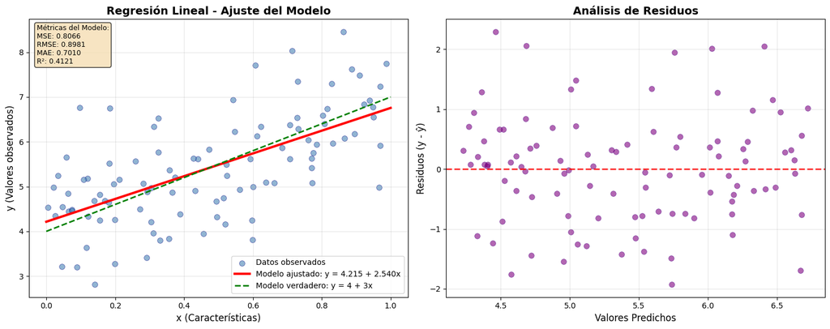

```
🔹 Métricas de evaluación del modelo:
   • MSE: 0.806585
   • RMSE: 0.898101
   • MAE: 0.701043
   • R²: 0.412086
✅ Resultados:
   • R² = 0.4121
   • Varianza explicada: 41.2%
   • Calidad: Regular
```

```python
# CELDA 3: Mostramos graficos
metricas = main_parte3(x, y, beta)
```

## 6)Resumen final del modelo-

```python
#Parte 4- Mostramos resultados de parametros
resumen = main_parte4(x, y, beta, X, metricas)
```

```
==================================================
4️⃣ RESUMEN FINAL
==================================================
📊 Datos procesados: 100 observaciones
🔧 Parámetros:
   • β₀ (intercepto): 4.215096
   • β₁ (pendiente): 2.540227
📈 Rendimiento: R² = 0.4121 (Regular)
⚡ Ajuste regular
```

# 📌 Conclusiones y Documentación del Modelo de Regresión Lineal

### 🧠 Descripción de Funciones (con docstrings incluidos en el código)

- **`generar_datos(n=100)`**  
  Genera datos sintéticos con una relación lineal más ruido gaussiano.
  - Entrada: número de datos `n`.
  - Salida: arrays `x` (independiente) e `y` (dependiente).
  - Propósito: Simular una situación real de datos dispersos en torno a una tendencia.
- **`ajustar_modelo(x, y)`**  
  Aplica álgebra matricial para estimar los coeficientes del modelo de regresión lineal.
  - Entrada: vectores `x` e `y`.
  - Salida: vector `beta` con los parámetros ajustados (intercepto y pendiente).
  - Propósito: Resolver el modelo β = (XᵀX)⁻¹Xᵀy mediante operaciones matriciales.
- **`graficar_resultado(x, y, beta)`**  
  Visualiza los datos originales y la línea ajustada.
  - Entrada: `x`, `y`, y los parámetros `beta`.
  - Salida: gráfica de dispersión + línea de regresión.
  - Propósito: Validar visualmente el ajuste del modelo sobre los datos generados.

### 🔁 Flujo del Modelo y Explicaciones Clave

- **Generación de datos**: Se simula un conjunto de puntos que siguen una relación lineal (pendiente = 3, intercepto = 4), pero con ruido, para representar incertidumbre o errores de medición reales.
- **Construcción de la matriz X**: En regresión lineal, necesitamos una matriz de diseño con una columna de 1s (para el término independiente) y la variable independiente `x`.
- **Uso de la fórmula matricial**:  
  Se aplica la expresión:

  $$ \boldsymbol{\beta} = (X^T X)^{-1} X^T y $$

  que permite resolver la regresión lineal sin métodos iterativos, aprovechando el álgebra matricial como herramienta eficiente y precisa.
- **Cálculo paso a paso**:
  - Transpuesta de `X` (`X.T`)
  - Producto matricial `X.T @ X`
  - Inversa de la matriz resultante
  - Multiplicación final para obtener `β`
- **Visualización**:  
  Es crucial para interpretar la calidad del modelo, evaluando si la recta estimada refleja correctamente la tendencia central de los datos.

### 📘 README: ¿Por qué usar Álgebra Matricial en Machine Learning?

La regresión lineal es uno de los modelos fundamentales del aprendizaje automático. Su implementación con álgebra matricial permite:

- Resolver el modelo de manera vectorizada y eficiente.
- Extender fácilmente a regresión múltiple (con varias variables).
- Comprender mejor algoritmos más avanzados que se basan en principios similares, como redes neuronales y métodos de mínimos cuadrados generalizados.
- Aprovechar librerías optimizadas como NumPy y acelerar cálculos para grandes volúmenes de datos.

Por tanto, dominar este enfoque no solo facilita la comprensión de la regresión lineal, sino que sienta las bases para algoritmos de mayor complejidad en el campo del ML.

✅ **Duración estimada de la actividad**: 2 a 3 horas  
👥 **Trabajo en parejas**  
🔁 **Semilla fija utilizada**: `np.random.seed(42)`  
📊 **Número de datos generados**: `n = 100`